# K-Means Presentation

## An Introduction to K-Means Clustering

Finding meaningful patterns within data has become obtrusive as data collection and management continues to grow.

K-Means Clustering caters to such voluminous & unlabeled data, utilizing

- Unsupervised learning
- Clustering
- Variance minimization techniques: distance calculations

## An Introduction to K-Means Clustering

There are 5 main steps to execute the K-Means Clustering method.

- Assign all data points to a cluster noted as ‘K’.
- Set ‘K’ random seed points.
- Reassign all data points to a cluster using distance to seed point.
- Compute the mean center of each new cluster noted as a centroid.
- Loop the re-assignment step of all data points to a new centroid based on its minimized relocation, until the centroid does not change.

## What is Unsupervised learning

- Statistical modeling technique used to categorize/group data without the assistance of historical results or human intervention.
- Autonomous data categorization
- Creates a data driven outcome

## Clustering

- Clustering is the act of partitioning data into meaningful groups based on similarity in attributes.
- The goal of clustering is to create insightful clusters to better understand connections in the data.
- k=4, the seed point are green, forming 4 respective clusters
- Once the initial assignemnt of centroids is made the Euclidean distance is used to establish cluster members by minimal distance noted as the red lines in the figure.

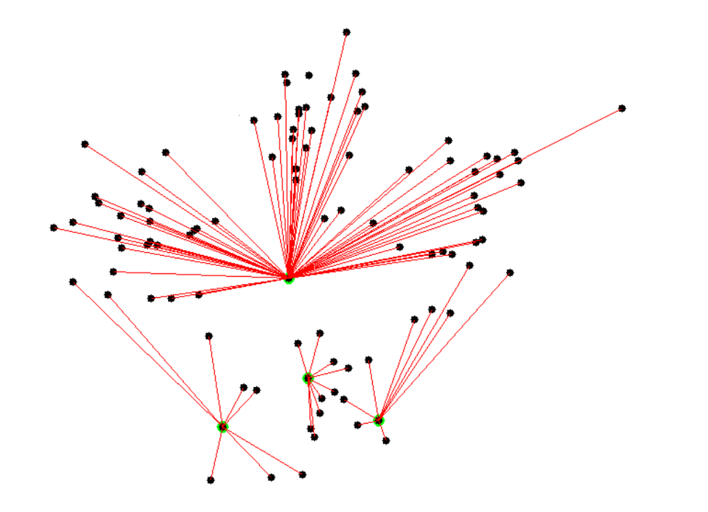

centroids

## Euclidean Distance

- Euclidean distance can be employed as a key metric to measure the dissimilarity between data points, facilitating the grouping of similar data instances into clusters using the K-Means clustering algorithm.

$$d(x,C_i)=sqrt(\sum_{i=1}^{N} (x_j−C_{ij})^2)$$

- Objective Function: The K-Means clustering objective is to minimize the within-cluster variance.

It is formulated as:

$$d(x,C_i)=(\sum_{i=1}^{k}*\sum_{x \in C_i}^{}(||x-\mu_i||)^2)$$

## Euclidean Distance

- $k$ is the number of clusters.
- $C_i$ represents the number of points in the cluster $i$
- $\mu_i$ represents the centroid mean of cluster $i$
- In this context, similarity is inversely related to the Euclidean distance
- The smaller the distance, the greater the similarity between objects
- K-Means Clustering reassigns the data points to each cluster based on the Euclidean Distance calculation.
- Each centroid location is updated by taking the position at each clusters mean center.

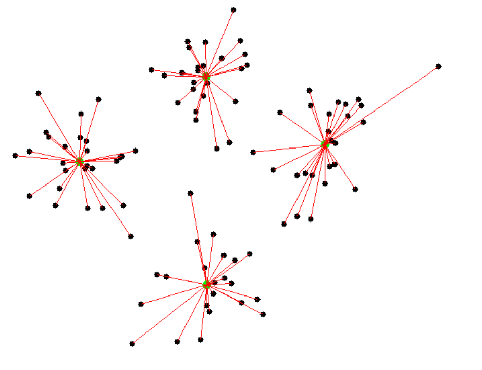

data points reassigned to centroids